# Introduction to Datasets

January 14, 2026 @ 08:46 PM

## Dataset Structure

## Essential Vocabulary

- A *variable* is some characteristic we are interested in that can differ between individuals in a population.
- A **unit of observational** (or *observation*) is a single individual, object, or entity about which we collect data, to describe one or more of its characteristics (variables).
- An observation may be called a case, subject, or participant.
- Ideally, each observational unit has a value for each variable.

A *dataset* is a collection of data values for the observations and variables in a study (e.g., survey or experiment). A common way to arrange data is to put variables in columns and observations in rows. This is what we call *tidy* data.

## Numerical Variables

Variables that can take on a range of numerical values, where it is sensible and meaningful to perform mathematical operations on those values, are **numerical** or **quantitative** variables. These often will include units of measure.

A **discrete** variable is a numerical variable that can only take on a finite or countably infinite number of distinct, separate values. These are often whole numbers or counts.

A **continuous** variable is a numerical variable that can have any value within a given range. The set of possible values is infinite. These include concepts like time, temperature, speed, or weight, which are limited in decimals only by our ability to measure.

Some variables that use numbers are not truly numerical, such as area codes or social security numbers.

## Categorical Variables

At the name suggests, **categorical** variables are categories into which we group characteristics, or labels for observation units, such as eye color, gender, or state names.

Categories that have a natural ordering, such as the grade levels freshman, sophomore, junior, and senior, are called **ordinal**.

If categories do not have a natural or meaningful ordering, then we call that a **nominal** categorical variable. Our IMS2E textbook treats all categorical variables as nominal.

For convenience, we could use numbers to represent categories, such as Democrat = 1, Republican = 2, Independent = 3, but they would still be categorical. We have to be careful of this when we use software for data analysis.

## “Levels of Measurement”

Some textbooks refer to a variable’s “level of measurement” and identify numerical variables as being **interval** or **ratio** type.

A **ratio** variable has a true zero, in the sense that zero means an absence of the characteristic that is being counted or measured. For example, if I have a bank balance of $0, I have no money, or a water level of zero in a reservoir means there is no water.

For a ratio variable, values have the proportions we expect from the real number line. For example, $6.00 is twice as much actual value as $3.00 (the ratio of quantities is 6/3 = 2).

An **interval** variable has fixed-sized units, but no true zero. For example, 0°C is not an absence of temperature (kinetic energy), and 100°C is not twice as hot as 50°C. However, each 1°C added is the same amount of additional energy.

## Hierarchy of Values

The levels of measurement framework has an innate hierarchy.

**levels:** nominal → ordinal → interval (discrete or continuous) → ratio (discrete or continuous)

Older versions of some data analysis programs like SPSS used to use these levels of measurement. Now SPSS uses three levels of measurement: Nominal, Ordinal, and Scale (grouping numerical Interval and Ratio scales together).

`R` does not make this variable distinction in quite the same way. We will discuss this when we use `R` to explore data.

## What is “Tidy” Data?

[figure not shown]

Tidy data graphic from [*R for Data Science: Tidy Data*](http://r4ds.had.co.nz/tidy-data.html)

Most of the datasets we will work with are already **tidy**, though there may be missing data and other issues we have to address before conducting analyses.

Real life data is often quite messy. We may explore a few ways to make datasets more tidy during this course.

## Variable Vectors in `R`

Each variable (column) in a tibble or dataset is a vector. These vectors may be of different types. It is helpful to visualize this when planning how to manipulate data.

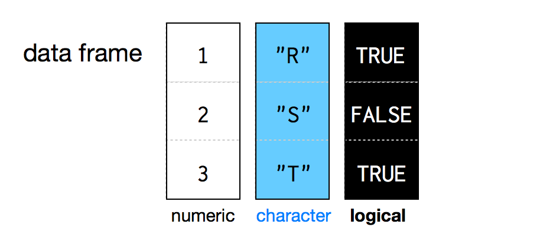

Data Frame Columns are Vectors (from [*Hands-On Programming with R*](https://rstudio-education.github.io/hopr/r-objects.html#data-frames))

## The Six Main Types of Vectors

| typeof (…) | mode (…) | storage.mode (…) |
| --- | --- | --- |
| logical (`TRUE` = `1` / `FALSE` = `0`) | logical | logical |
| integer | numeric | integer |
| double | numeric | double* |
| complex | complex | complex |
| character (alphanumeric, string) | character | character |
| raw (contains raw bytes) | raw | raw |

* double precision floating point (a method by which computers store decimal numbers; 64 bits or 8 bytes of memory)

## Exploring Datasets

## What’s in a Dataset?

Before doing any kind of data modeling or inference, you need to examine your dataset and become familiar with its structure and contents—this is *exploratory data analysis (EDA)*.

John Tukey (1915–2000), author of the seminal book *Exploratory Data Analysis* (1977), referred to EDA as numerical, counting, and graphical detective work. He is also credited with introducing the now-familiar terms “bit” and “software” while working with early computers at Bell Labs.

We will use the *dplyr* and *ggplot2* packages for manipulation and visualization. These tools and more are part of the [tidyverse](https://www.tidyverse.org/).

`R` has many functions that help us explore datasets and discover their properties/variables.

## Datasets in `R`

A data frame or tibble is a two dimensional structure/array in `R`. It is a special case of a list where each component (column) has equal length and can contain a different variable type.

The core installation of `R` (i.e., `{base} R`) includes many built-in datasets. We can get a list using the `data()` function.

Entering `data()` in the Console pane of RStudio will open a new tab/window listing the names of all the built-in datasets.

We can get a list of the datasets found in other packages using `data(package = "packagename")`. For example, all the data in ggplot2 can be found using `data(package = "ggplot2")`.

Try `data(package = .packages(all.available = TRUE))` .

## Example Dataset

Consider the `Nightingale` dataset from the HistData package.

Load the HistData package using the `library()` function. Let’s assign the dataset to an object in our environment.

```r
library(HistData)
nightingale <- Nightingale   # all lowercase can be more convenient
```

Examine the dataset in your **Environment** pane.

- How many variables (columns) are there?
- What is the vector type for each of the variables?
- How many observational units/cases (rows) are there? What does each case represent?

## Environment Pane

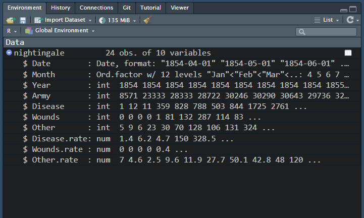

## `View()` the Dataset

Use `View(nightingale)` or click on the name of the dataset in the Environment pane to visualize the structure; the rows (units of observation) and columns (variables). Works best for smaller datasets, with a few variables that fit into the window view.

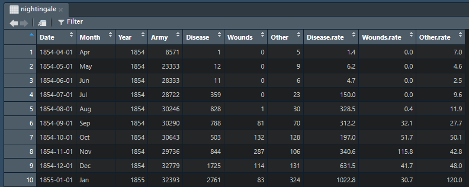

## Some Functions for Exploring

The environment pane is using functions behind the scenes to display some of the information we can see. We can use these functions directly to explore dataset structure.

`head()` / `tail()` are closely related; so are `str()` / `glimpse()`

```r
head(nightingale)     # this function is part of base R code
```

```r
tail(nightingale)     # this function is part of base R code
```

```r
str(nightingale)      # this function is part of base R code
```

```r
library(tidyverse)
glimpse(nightingale)  # this function is from package dplyr
```

## Visualize Structure

What information does `str()` give you about the dataset?

```r
str(nightingale)     # this function is part of base R code
```

```
'data.frame':   24 obs. of  10 variables:
 $ Date        : Date, format: "1854-04-01" "1854-05-01" ...
 $ Month       : Ord.factor w/ 12 levels "Jan"<"Feb"<"Mar"<..: 4 5 6 7 8 9 10 11 12 1 ...
 $ Year        : int  1854 1854 1854 1854 1854 1854 1854 1854 1854 1855 ...
 $ Army        : int  8571 23333 28333 28722 30246 30290 30643 29736 32779 32393 ...
 $ Disease     : int  1 12 11 359 828 788 503 844 1725 2761 ...
 $ Wounds      : int  0 0 0 0 1 81 132 287 114 83 ...
 $ Other       : int  5 9 6 23 30 70 128 106 131 324 ...
 $ Disease.rate: num  1.4 6.2 4.7 150 328.5 ...
 $ Wounds.rate : num  0 0 0 0 0.4 ...
 $ Other.rate  : num  7 4.6 2.5 9.6 11.9 27.7 50.1 42.8 48 120 ...
```

How are the outputs of `str()` and `glimpse()` similar? How are they different? Which does the RStudio Environment pane use?

```r
glimpse(nightingale)
```

```
Rows: 24
Columns: 10
$ Date         <date> 1854-04-01, 1854-05-01, 1854-06-01, 1854-07-01, 1854-08-…
$ Month        <ord> Apr, May, Jun, Jul, Aug, Sep, Oct, Nov, Dec, Jan, Feb, Ma…
$ Year         <int> 1854, 1854, 1854, 1854, 1854, 1854, 1854, 1854, 1854, 185…
$ Army         <int> 8571, 23333, 28333, 28722, 30246, 30290, 30643, 29736, 32…
$ Disease      <int> 1, 12, 11, 359, 828, 788, 503, 844, 1725, 2761, 2120, 120…
$ Wounds       <int> 0, 0, 0, 0, 1, 81, 132, 287, 114, 83, 42, 32, 48, 49, 209…
$ Other        <int> 5, 9, 6, 23, 30, 70, 128, 106, 131, 324, 361, 172, 57, 37…
$ Disease.rate <dbl> 1.4, 6.2, 4.7, 150.0, 328.5, 312.2, 197.0, 340.6, 631.5, …
$ Wounds.rate  <dbl> 0.0, 0.0, 0.0, 0.0, 0.4, 32.1, 51.7, 115.8, 41.7, 30.7, 1…
$ Other.rate   <dbl> 7.0, 4.6, 2.5, 9.6, 11.9, 27.7, 50.1, 42.8, 48.0, 120.0, …
```

## Other Useful Functions

A few functions for exploring dataset structure are given below. What information does each give you?

- `attributes()`
- `names()`
- `dim()`
- `nrow()`
- `ncol()`
- `head()`
- `tail()`
- `sum(complete.cases())` # this is two nested functions
- `sum(!complete.cases())` # what does the ! do?

```r
attributes(nightingale)
```

```
$names
 [1] "Date"         "Month"        "Year"         "Army"         "Disease"
 [6] "Wounds"       "Other"        "Disease.rate" "Wounds.rate"  "Other.rate"

$row.names
 [1]  1  2  3  4  5  6  7  8  9 10 11 12 13 14 15 16 17 18 19 20 21 22 23 24

$class
[1] "data.frame"
```

```r
names(nightingale)
```

```
 [1] "Date"         "Month"        "Year"         "Army"         "Disease"
 [6] "Wounds"       "Other"        "Disease.rate" "Wounds.rate"  "Other.rate"
```

```r
row.names(nightingale)
```

```
 [1] "1"  "2"  "3"  "4"  "5"  "6"  "7"  "8"  "9"  "10" "11" "12" "13" "14" "15"
[16] "16" "17" "18" "19" "20" "21" "22" "23" "24"
```

```r
class(nightingale)
```

```
[1] "data.frame"
```

```r
typeof(nightingale)
```

```
[1] "list"
```

```r
dim(nightingale)
```

```
[1] 24 10
```

## Explore some more datasets!

Try exploring some of the datasets in the HistData package, or those you can find in `R` and the tidyverse packages. You will see some of these pop up in DataCamp courses.

Practice to become proficient in loading data and investigating structure so you can start the important work of transforming raw data into useful information and knowledge.

These functions also will be useful when you manipulate data. They can help you can check that you achieve the structure you want/need. For example…

- Did you create a new variable properly?
- Did you filter out any cases you did not want?
- Did you successfully rearrange or “tidy” the data?

## Build from Scratch

## Using `data.frame()`

We can build a dataset from scratch (i.e., from vectors) using the `data.frame()` function.

Within the `data.frame()` function, we specify *variable name* = *a vector of values for the variable*. All the vectors must be the same length (i.e., same number of cases).

```r
dataset1 <- data.frame(
  ID = 1:5,
  gender = c("male", "male", "female", "female", "nonbinary"),
  height = c(71, 73, 64, 64, 66),
  weight = c(175, 225, 130, 125, 165)
)
```

Notice the structure of the code, including the indenting and `()`.

```r
glimpse(dataset1)
```

```
Rows: 5
Columns: 4
$ ID     <int> 1, 2, 3, 4, 5
$ gender <chr> "male", "male", "female", "female", "nonbinary"
$ height <dbl> 71, 73, 64, 64, 66
$ weight <dbl> 175, 225, 130, 125, 165
```

```r
head(dataset1)
```

```
  ID    gender height weight
1  1      male     71    175
2  2      male     73    225
3  3    female     64    130
4  4    female     64    125
5  5 nonbinary     66    165
```

## Using `tibble()`

A tibble is an “upgraded” dataset structure from the tidyverse. However, it works very similarly to `data.frame()`.

```r
dataset2 <- tibble(
  ID = 1:5,
  gender = c("male", "male", "female", "female", "nonbinary"),
  height = c(71, 73, 64, 64, 66),
  weight = c(175, 225, 130, 125, 165)
)
```

How else are the different? Use your exploratory functions!

```r
glimpse(dataset1)
```

```
Rows: 5
Columns: 4
$ ID     <int> 1, 2, 3, 4, 5
$ gender <chr> "male", "male", "female", "female", "nonbinary"
$ height <dbl> 71, 73, 64, 64, 66
$ weight <dbl> 175, 225, 130, 125, 165
```

```r
glimpse(dataset2)
```

```
Rows: 5
Columns: 4
$ ID     <int> 1, 2, 3, 4, 5
$ gender <chr> "male", "male", "female", "female", "nonbinary"
$ height <dbl> 71, 73, 64, 64, 66
$ weight <dbl> 175, 225, 130, 125, 165
```

## Example with Missing Data

`NA` is `R`’s system character for missing data, similar to how `NULL` means that there is no vector (vector of length zero).

```r
library(tidyverse)
dataset3 <- tibble(
  ID = c(1, 2, 4, 5, 7),
  sex = c("male", "male", "female", "nonbinary", NA),
  visits = c(1, 2, 4, 12, 2),
  checkup = c(1, 1, 1, 1, 1),
  follow_up = c(NA, 0, 1, 2, 0),
  illness = c(0, 0, 2, 7, 1 ),
  surgery = c(0, 0, 0, 2, 0),
  ER = c(0, 1, 0, 0, NA),
  Test = NULL
)
```

```r
glimpse(dataset3)
```

```
Rows: 5
Columns: 8
$ ID        <dbl> 1, 2, 4, 5, 7
$ sex       <chr> "male", "male", "female", "nonbinary", NA
$ visits    <dbl> 1, 2, 4, 12, 2
$ checkup   <dbl> 1, 1, 1, 1, 1
$ follow_up <dbl> NA, 0, 1, 2, 0
$ illness   <dbl> 0, 0, 2, 7, 1
$ surgery   <dbl> 0, 0, 0, 2, 0
$ ER        <dbl> 0, 1, 0, 0, NA
```

Use your other exploratory functions. Also, what happened to the `Test` variable?